# Casestudy1

## This can be found on GitHub at https://github.com/SMU-UNO/R-CasetStudy1

## Loading the necessary files into R.

```r
breweries.url <- "https://raw.githubusercontent.com/SMU-UNO/R-CasetStudy1/master/RawData/Breweries.csv" #location of the Breweries data
breweries <- read.csv(breweries.url, header=TRUE, sep = ",") #Loading into R
beers.url <- "https://raw.githubusercontent.com/SMU-UNO/R-CasetStudy1/master/RawData/Beers.csv" #location of the Breweries data
beers <- read.csv(beers.url, header=TRUE, sep = ",") #Loading into R
```

## 1. How many breweries are present in each state?

```r
table(breweries$State)
```

```
##
##  AK  AL  AR  AZ  CA  CO  CT  DC  DE  FL  GA  HI  IA  ID  IL  IN  KS  KY
##   7   3   2  11  39  47   8   1   2  15   7   4   5   5  18  22   3   4
##  LA  MA  MD  ME  MI  MN  MO  MS  MT  NC  ND  NE  NH  NJ  NM  NV  NY  OH
##   5  23   7   9  32  12   9   2   9  19   1   5   3   3   4   2  16  15
##  OK  OR  PA  RI  SC  SD  TN  TX  UT  VA  VT  WA  WI  WV  WY
##   6  29  25   5   4   1   3  28   4  16  10  23  20   1   4
```

## 2. Merge beer data with the breweries data. Print the first 6 observations and the last six observations to check the merged file.

```r
beersnbrew <- merge(beers, breweries, by.x=c("Brewery_id"), by.y = c("Brew_ID"), all=FALSE)
head(beersnbrew)
```

```
##   Brewery_id        Name.x Beer_ID   ABV IBU
## 1          1  Get Together    2692 0.045  50
## 2          1 Maggie's Leap    2691 0.049  26
## 3          1    Wall's End    2690 0.048  19
## 4          1       Pumpion    2689 0.060  38
## 5          1    Stronghold    2688 0.060  25
## 6          1   Parapet ESB    2687 0.056  47
##                                 Style Ounces             Name.y
## 1                        American IPA     16 NorthGate Brewing
## 2                  Milk / Sweet Stout     16 NorthGate Brewing
## 3                   English Brown Ale     16 NorthGate Brewing
## 4                         Pumpkin Ale     16 NorthGate Brewing
## 5                     American Porter     16 NorthGate Brewing
## 6 Extra Special / Strong Bitter (ESB)     16 NorthGate Brewing
##          City State
## 1 Minneapolis    MN
## 2 Minneapolis    MN
## 3 Minneapolis    MN
## 4 Minneapolis    MN
## 5 Minneapolis    MN
## 6 Minneapolis    MN
```

```r
tail(beersnbrew)
```

```
##      Brewery_id                    Name.x Beer_ID   ABV IBU
## 2405        556             Pilsner Ukiah      98 0.055  NA
## 2406        557  Heinnieweisse Weissebier      52 0.049  NA
## 2407        557           Snapperhead IPA      51 0.068  NA
## 2408        557         Moo Thunder Stout      50 0.049  NA
## 2409        557         Porkslap Pale Ale      49 0.043  NA
## 2410        558 Urban Wilderness Pale Ale      30 0.049  NA
##                        Style Ounces                        Name.y
## 2405         German Pilsener     12         Ukiah Brewing Company
## 2406              Hefeweizen     12       Butternuts Beer and Ale
## 2407            American IPA     12       Butternuts Beer and Ale
## 2408      Milk / Sweet Stout     12       Butternuts Beer and Ale
## 2409 American Pale Ale (APA)     12       Butternuts Beer and Ale
## 2410        English Pale Ale     12 Sleeping Lady Brewing Company
##               City State
## 2405         Ukiah    CA
## 2406 Garrattsville    NY
## 2407 Garrattsville    NY
## 2408 Garrattsville    NY
## 2409 Garrattsville    NY
## 2410     Anchorage    AK
```

## 3. Report the number of NA’s in each column

```r
colSums(is.na(beersnbrew))
```

```
## Brewery_id     Name.x    Beer_ID        ABV        IBU      Style
##          0          0          0         62       1005          0
##     Ounces     Name.y       City      State
##          0          0          0          0
```

## 4.Compute the median alcohol content and international bitterness unit for each state. Plot a bar chart to compare.

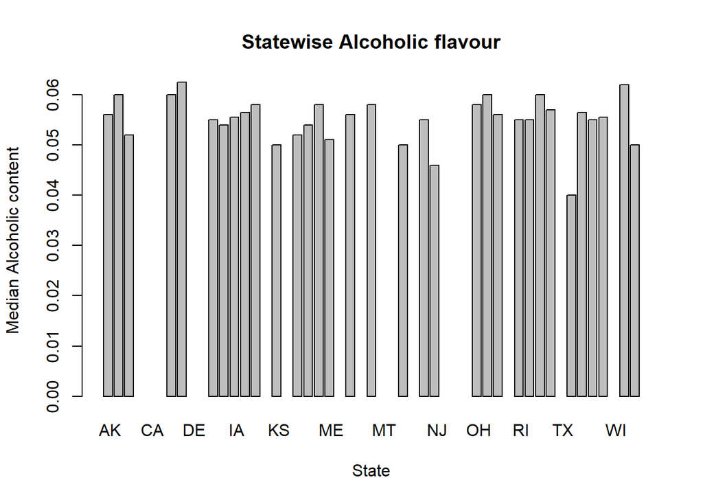

```r
med.ABV<-tapply(beersnbrew$ABV, beersnbrew$State, median)
med.IBU<-tapply(beersnbrew$IBU, beersnbrew$State, median)
barplot(med.ABV, xlab="State", ylab="Median Alcoholic content", main ="Statewise Alcoholic flavour")
```

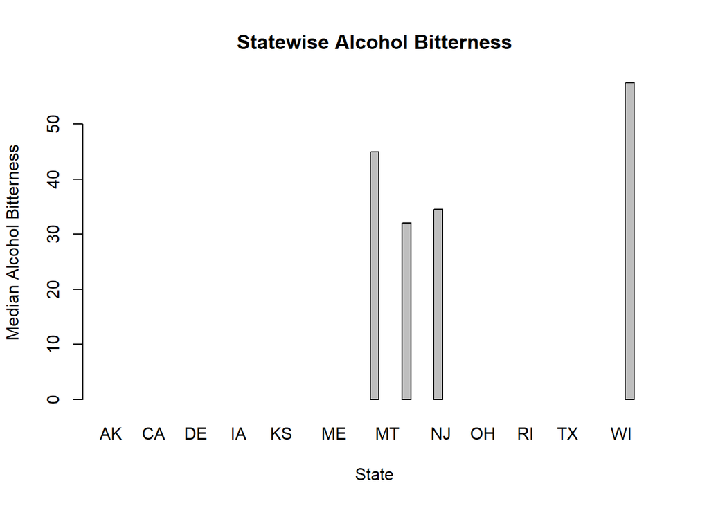

```r
barplot(med.IBU, xlab="State", ylab="Median Alcohol Bitterness", main ="Statewise Alcohol Bitterness")
```

## 5. Which state has the maximum alcoholic (ABV) beer? Which state has the most bitter (IBU) beer?

```r
maxABV <- beersnbrew[which.max(beersnbrew$ABV), ]
maxABVState<-levels(droplevels(maxABV$State))
print("State with maximum alcoholic (ABV) beer ")
```

```
## [1] "State with maximum alcoholic (ABV) beer "
```

```r
maxABVState
```

```
## [1] " CO"
```

```r
maxIBU <- beersnbrew[which.max(beersnbrew$IBU), ]
maxIBUState<-levels(droplevels(maxIBU$State))
print("State with the most bitter (IBU) beer ")
```

```
## [1] "State with the most bitter (IBU) beer "
```

```r
maxIBUState
```

```
## [1] " OR"
```

```r
summary(beersnbrew$ABV)
```

```
##    Min. 1st Qu.  Median    Mean 3rd Qu.    Max.    NA's
## 0.00100 0.05000 0.05600 0.05977 0.06700 0.12800      62
```

## 7.Is there an apparent relationship between the bitterness of the beer and its alcoholic content? Draw a scatter plot.

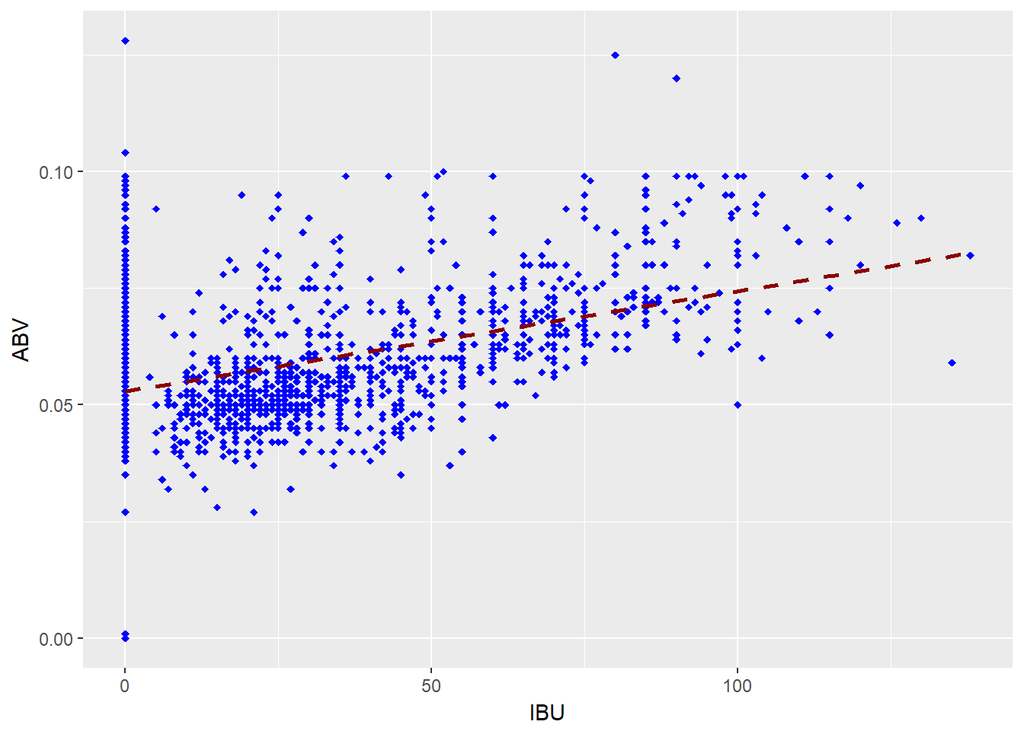

```r
beersnbrew[is.na(beersnbrew)] <- 0

library(ggplot2)
ggplot(beersnbrew, aes(x=IBU, y=ABV)) +
geom_point(shape=18, color="blue")+
geom_smooth(method=lm, se=FALSE, linetype="dashed",
color="darkred")
```

## If the data points make a straight line going from the origin out to high x- and y-values, then the variables are said to have a positive correlation .

# If the line goes from a high-value on the y-axis down to a high-value on the x-axis, the variables have a negative correlation .

## The figure, seems to be a fuzzy linear correlation so we will use Correlation Coefficient in order to measure of the linear dependence between IBU and ABV.

```r
cc <- cor(beersnbrew$ABV, beersnbrew$IBU)
cc
```

```
## [1] 0.3790309
```

## the r value we got is 0.4 showing the slight positive corealtion between the IBU ans ABV that the alcoholic content may effect to the flavour or bitterness of alcohol.